# Analyzing Employee Compensation and Benefits

### Load libraries and Data

```r
library(tidyverse)
```

```r
library(ggplot2)
library(dplyr)
salary <- readxl::read_xlsx('Data Analytics DataSet.xlsx')
salary<-salary %>% mutate(compensation = Total-Basic)
is.na(salary)%>%sum()
```

```
## [1] 0
```

### The Banks used by our Employees

```r
banks <- salary %>%
  select(Bank) %>%
  distinct()

banks
```

```
## # A tibble: 6 × 1
##   Bank
##   <chr>
## 1 Sub-Standard Bank
## 2 Distressed Bank
## 3 Oasis Bank
## 4 Money Doublers' Bank
## 5 Atlantic Bank
## 6 Last Bank Of Nigeria
```

### The Total number of Personnels in each department

```r
dept <- salary %>%
  select(Department) %>%
  group_by(Department) %>%
  mutate(Total =n()) %>%
  distinct()

dept
```

```
## # A tibble: 10 × 2
## # Groups:   Department [10]
##    Department       Total
##    <chr>            <int>
##  1 Finance            172
##  2 Human Resources    220
##  3 Admin.             140
##  4 Internal Control    66
##  5 IT                  69
##  6 R&D                 66
##  7 Dispatch            66
##  8 Production          66
##  9 Customer Service    69
## 10 Quality Control     66
```

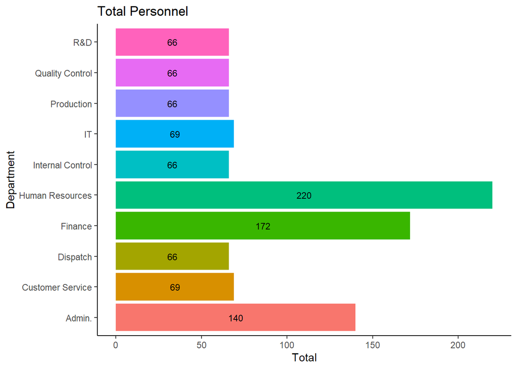

```r
dept_graph <- dept %>% ggplot(aes(Department,Total, fill = Department)) + geom_col() +
  theme_classic() +
  labs(title = "Total Personnel ") +
  theme(legend.position = "none") +
  geom_text(aes(label = Total),
            position = position_stack(vjust = 0.5),
            color ="black", size = 3) + coord_flip()

dept_graph
```

***

### Average Compensation per department

```r
Compensation_dept <- salary %>% aggregate(compensation~Department, FUN = mean)%>% arrange(compensation)

Compensation_dept
```

```
##          Department compensation
## 1  Internal Control     558930.9
## 2                IT     582182.0
## 3               R&D     583974.6
## 4        Production     601887.4
## 5            Admin.     615944.5
## 6   Human Resources     628634.4
## 7           Finance     629670.1
## 8  Customer Service     638422.4
## 9   Quality Control     640704.0
## 10         Dispatch     659166.4
```

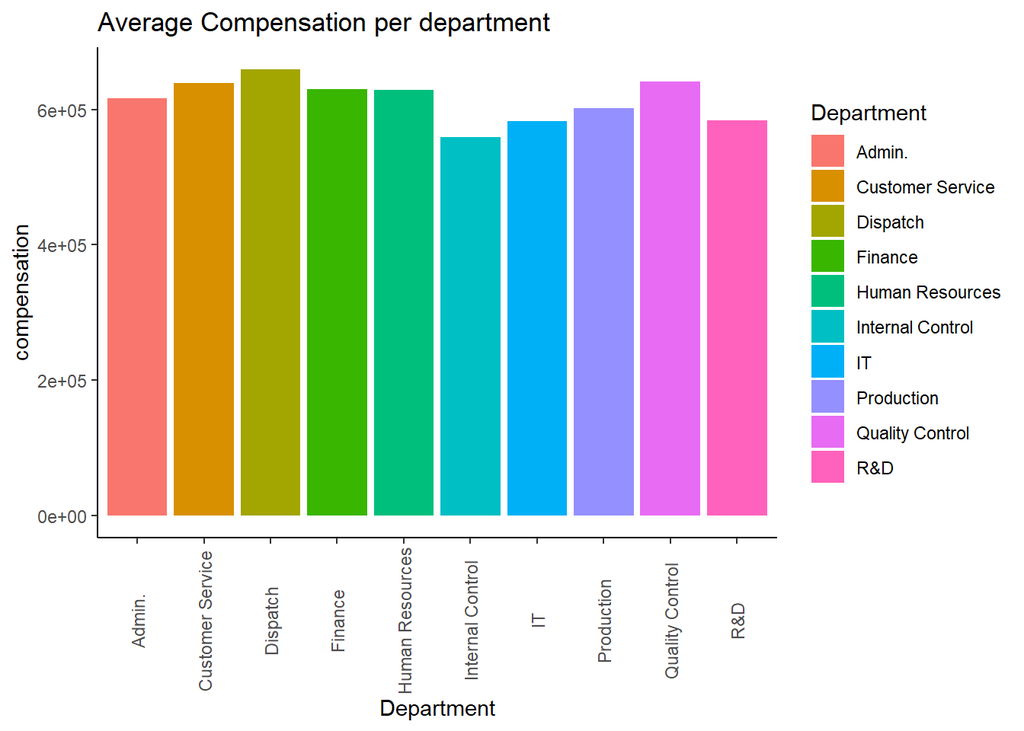

```r
Compensation_dept_graph <- Compensation_dept %>% ggplot(aes(Department,compensation, fill = Department)) + geom_bar(stat = 'identity')  +
  theme_classic() +  ggtitle("Average Compensation per department") + theme(axis.text.x = element_text(angle = 90, vjust = 0.5))



Compensation_dept_graph
```

```r
banks_pay <- salary %>%
  aggregate(Total~Bank,
            FUN = 'mean')

banks_pay
```

```
##                   Bank   Total
## 1        Atlantic Bank 2859539
## 2      Distressed Bank 3161746
## 3 Last Bank Of Nigeria 3143976
## 4 Money Doublers' Bank 3272898
## 5           Oasis Bank 3108603
## 6    Sub-Standard Bank 3222421
```

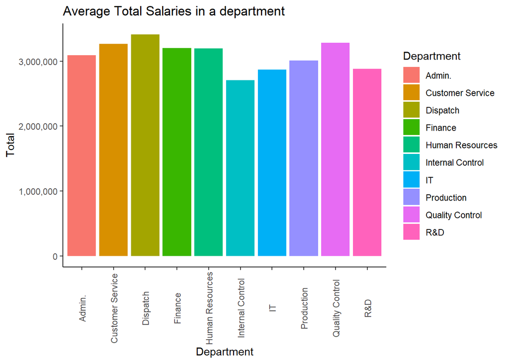

```r
dept_pay_mean <- salary %>%
  aggregate(Total ~ Department,
            FUN = mean) %>%
  arrange(Total) %>%
  head(10)


dept_pay_mean_graph <-
  dept_pay_mean %>%
  ggplot(aes(Department,
             Total,
             fill = Department)) +
  geom_bar(stat = 'identity') +
  scale_y_continuous(labels = scales::comma) +
  theme_classic() +
 ggtitle("Average Total Salaries in a department") + theme(axis.text.x = element_text(angle = 90, vjust = 0.5))


dept_pay_mean_graph
```

```r
dept_pay_max <- salary %>%
  aggregate(Total ~ Department,
            FUN = max) %>% arrange(desc(Total)) %>% head(10)

dept_pay_max
```

```
##          Department   Total
## 1  Customer Service 6001580
## 2  Internal Control 5998834
## 3            Admin. 5969220
## 4          Dispatch 5969002
## 5           Finance 5957610
## 6               R&D 5933632
## 7   Human Resources 5927426
## 8   Quality Control 5911278
## 9                IT 5830206
## 10       Production 5816035
```

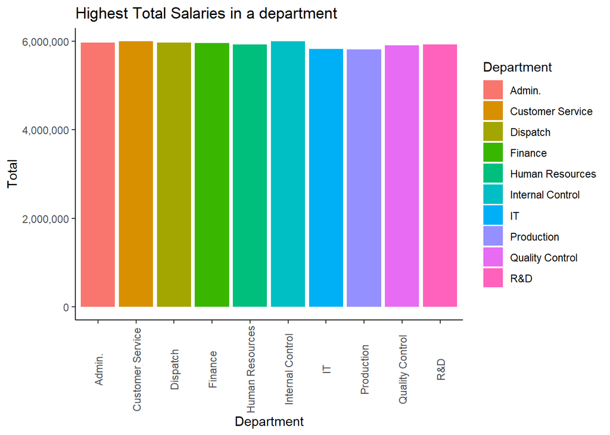

```r
dept_graph_max <- dept_pay_max %>%
  ggplot(aes(Department,
             Total,
             fill = Department)) +
  geom_bar(stat = 'identity') +
  scale_y_continuous(labels = scales::comma) +
  theme_classic() + ggtitle("Highest Total Salaries in a department") + theme(axis.text.x = element_text(angle = 90, vjust = 0.5))

dept_graph_max
```

```r
dept_pay_min <- salary %>%
  aggregate(Total ~ Department,
            FUN = max) %>%
  arrange(Total) %>%
  head(10)

dept_graph_min <- dept_pay_min %>%
  ggplot(aes(Department,
             Total,
             fill = Department)) +
  geom_col() +
  theme_classic() +
  ggtitle("Lowest Total Salaries in a department") +
  scale_y_continuous(labels = scales::comma) +
  theme(axis.text.x = element_text(angle = 90, vjust = 0.5))


dept_pay_min
```

```
##          Department   Total
## 1        Production 5816035
## 2                IT 5830206
## 3   Quality Control 5911278
## 4   Human Resources 5927426
## 5               R&D 5933632
## 6           Finance 5957610
## 7          Dispatch 5969002
## 8            Admin. 5969220
## 9  Internal Control 5998834
## 10 Customer Service 6001580
```

[figure not shown]

```r
dept_graph_min
```

***

### The Average, Highest and Lowest Basic Salaries earned in a department

```r
dept_basic <- salary %>%
  aggregate(Basic~ Department,
            FUN = mean) %>%
  arrange(desc(Basic)) %>%
  head(10)

dept_basic
```

```
##          Department   Basic
## 1          Dispatch 2751243
## 2   Quality Control 2640024
## 3  Customer Service 2626280
## 4           Finance 2573555
## 5   Human Resources 2567316
## 6            Admin. 2477347
## 7        Production 2406189
## 8               R&D 2298281
## 9                IT 2287482
## 10 Internal Control 2147415
```

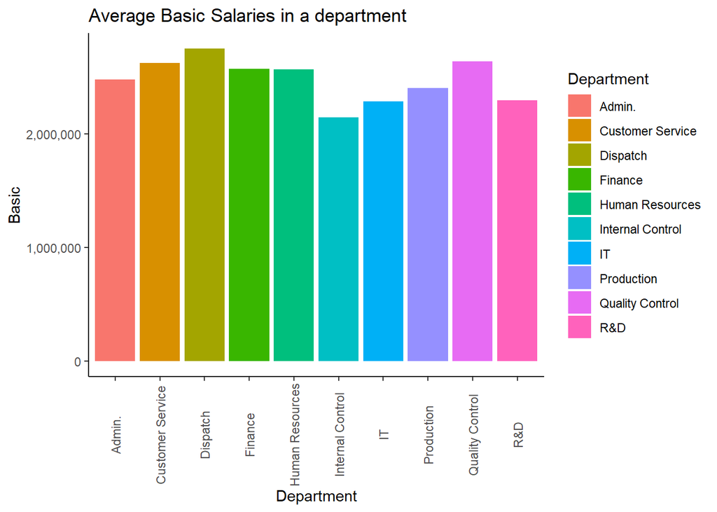

```r
dept_basic_graph <- dept_basic%>%
  ggplot(aes(Department,
             Basic,
             fill = Department)) +
  geom_col() +
  scale_y_continuous(labels = scales::comma)  +
  theme_classic() +
  ggtitle("Average Basic Salaries in a department") +
  theme(axis.text.x = element_text(angle = 90, vjust = 0.5))

dept_basic_graph
```

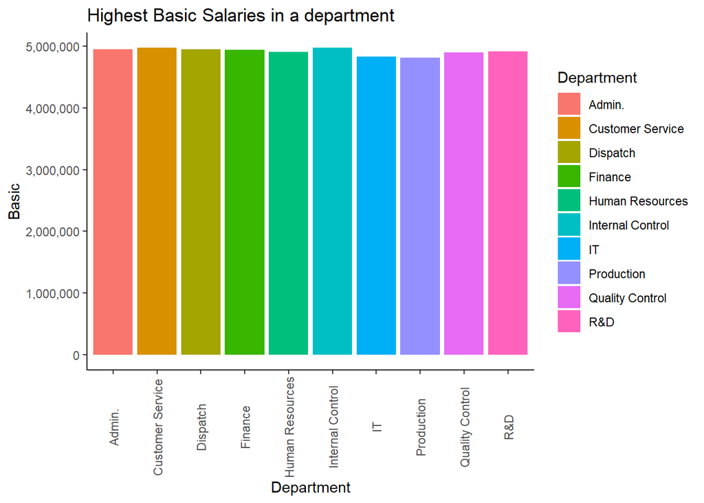

```r
dept_basic_max <- salary %>%
  aggregate(Basic~ Department,
            FUN = max) %>%
  arrange(desc(Basic)) %>%
  head(10)



dept_basic_max_graph<-dept_basic_max %>%
  ggplot(aes(Department,Basic,fill = Department)) +
  geom_col() +scale_y_continuous(labels = scales::comma)+
  theme_classic()  +
  theme_classic()  +
  ggtitle("Highest Basic Salaries in a department") +
  theme(axis.text.x = element_text(angle = 90, vjust = 0.5))


dept_basic_max_graph
```

```r
dept_basic_min <-  salary %>%
  aggregate(Basic~ Department,
            FUN = min) %>%
  arrange(Basic) %>%
  head(10)



dept_basic_min
```

```
##          Department     Basic
## 1            Admin.  58975.77
## 2   Human Resources 104316.00
## 3  Internal Control 104608.00
## 4               R&D 105180.00
## 5           Finance 124539.00
## 6  Customer Service 127102.00
## 7   Quality Control 127431.00
## 8                IT 132878.00
## 9        Production 149773.00
## 10         Dispatch 194232.00
```

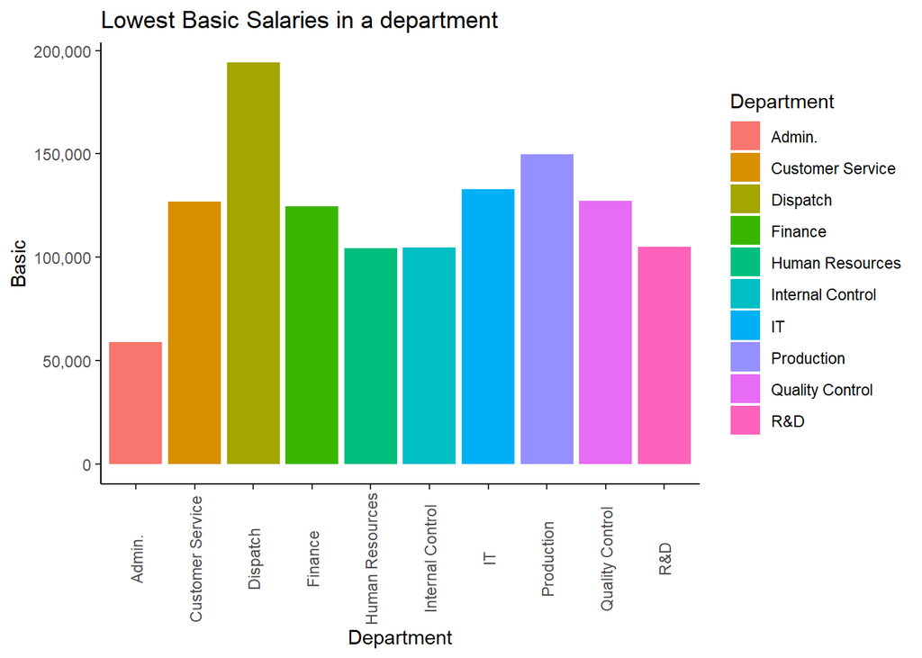

```r
dept_basic_min_graph <- dept_basic_min %>%
  ggplot(aes(Department,Basic,fill = Department)) +
  geom_col() +
  scale_y_continuous(labels = scales::comma)+
  theme_classic()+
  ggtitle("Lowest Basic Salaries in a department") +
  theme(axis.text.x = element_text(angle = 90, vjust = 0.5))


dept_basic_min_graph
```

```r
t.test(salary$compensation,data = salary)
```

```
##
##  One Sample t-test
##
## data:  salary$compensation
## t = 83.304, df = 999, p-value < 2.2e-16
## alternative hypothesis: true mean is not equal to 0
## 95 percent confidence interval:
##  603446.5 632562.6
## sample estimates:
## mean of x
##  618004.5
```

### The Average, Highest and Lowest Basic Salaries earned in their respective Units

```r
unit_basic_mean <- salary %>%
  aggregate(Basic~Unit,FUN = mean) %>%
  arrange(Basic) %>%
  head(10)


unit_basic_mean
```

```
##                            Unit   Basic
## 1                 Fraud Control 2094968
## 2                    Compliance 2136500
## 3                      Analysis 2147172
## 4               Desktop Support 2148568
## 5               Risk Management 2210777
## 6  Business Application Support 2222960
## 7              Technical Design 2261071
## 8                      Planning 2277068
## 9                  Social Media 2290914
## 10       Planning & Development 2349087
```

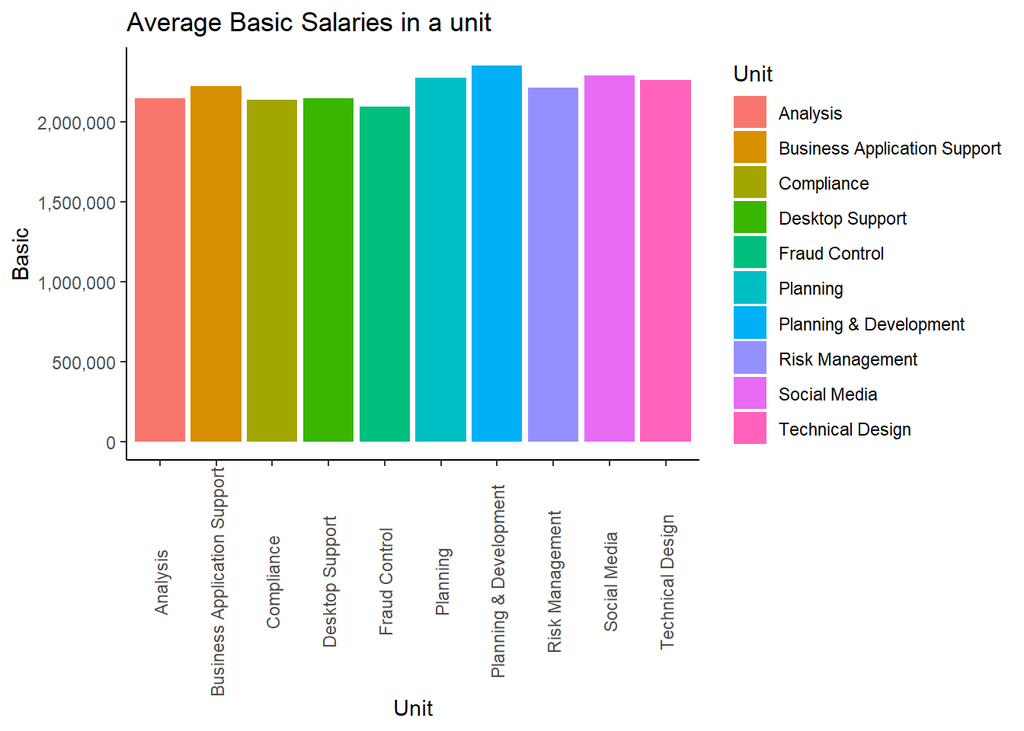

```r
unit_basic_mean_graph <- unit_basic_mean %>%
  ggplot(aes(Unit,Basic,fill = Unit)) +
  geom_col() +
  scale_y_continuous(labels = scales::comma)  +
  theme_classic()+
  ggtitle("Average Basic Salaries in a unit") +
  theme(axis.text.x = element_text(angle = 90, vjust = 0.5))



unit_basic_mean_graph
```

```r
unit_basic_max <- salary %>%
  aggregate(Basic~Unit,FUN = max) %>%
  arrange(desc(Basic)) %>%
  head(10)


unit_basic_max
```

```
##                Unit   Basic
## 1      Social Media 4973516
## 2   Risk Management 4971161
## 3       Call Center 4963737
## 4          Supplies 4945763
## 5           Courier 4945576
## 6         Budgeting 4935806
## 7     Fraud Control 4921564
## 8  Account Payables 4917072
## 9       MD's Office 4915905
## 10           Design 4915242
```

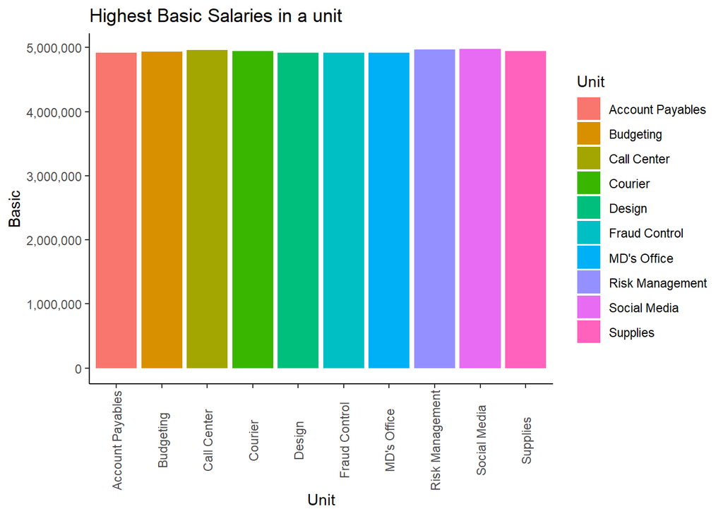

```r
unit_basic_max_graph <- unit_basic_max%>%
  ggplot(aes(Unit,Basic,fill = Unit)) +
  geom_col() +
  scale_y_continuous(labels = scales::comma)  +
  theme_classic() +
  ggtitle("Highest Basic Salaries in a unit") +
  theme(axis.text.x = element_text(angle = 90, vjust = 0.5))


unit_basic_max_graph
```

```r
unit_basic_min  <- salary %>%
  aggregate(Basic~Unit,FUN = min) %>%
  arrange(Basic) %>% head(10)


unit_basic_min
```

```
##                      Unit     Basic
## 1             Expenditure  58975.77
## 2                 Payroll 104316.00
## 3              Compliance 104608.00
## 4                  Design 105180.00
## 5  Training & Development 105295.00
## 6     Account Receivables 124539.00
## 7            Social Media 127102.00
## 8                Training 127431.00
## 9               Budgeting 128826.00
## 10        Desktop Support 132878.00
```

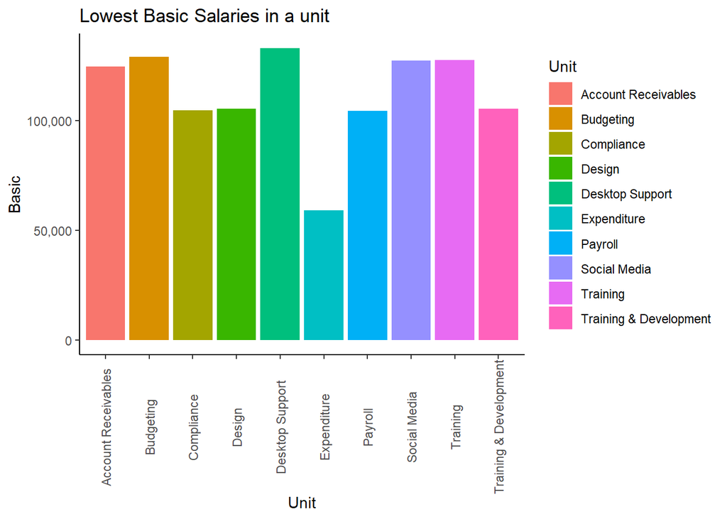

```r
 unit_basic_min_graph <- unit_basic_min%>%
   ggplot(aes(Unit,Basic,fill = Unit)) +
   geom_col() +scale_y_continuous(labels = scales::comma)  +
   theme_classic() +
   ggtitle("Lowest Basic Salaries in a unit") +
   theme(axis.text.x = element_text(angle = 90, vjust = 0.5))


 unit_basic_min_graph
```

***

### The Average, Highest and Lowest Total Salaries earned in their Units

```r
unit_total_mean <- salary %>%
  aggregate(Total~Unit,FUN = mean) %>%
  arrange(Total) %>%
  head(10)

unit_total_mean
```

```
##                            Unit   Total
## 1                 Fraud Control 2645192
## 2                    Compliance 2693619
## 3                      Analysis 2706063
## 4               Desktop Support 2707690
## 5               Risk Management 2780226
## 6  Business Application Support 2794432
## 7              Technical Design 2838869
## 8                      Planning 2857522
## 9                  Social Media 2873666
## 10       Planning & Development 2941495
```

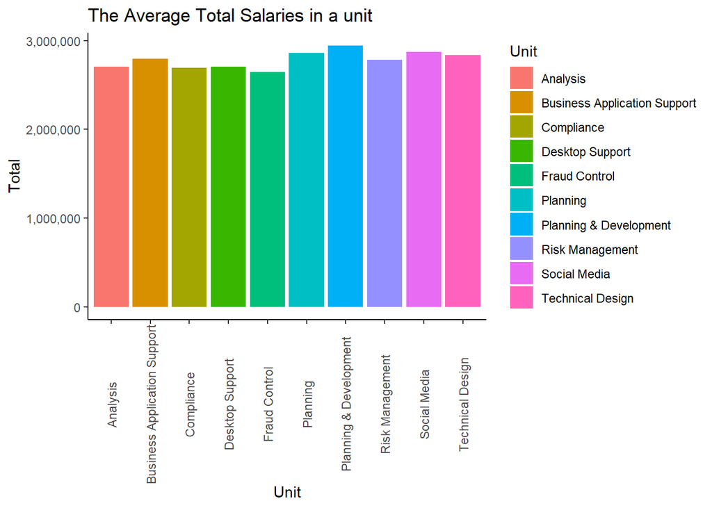

```r
unit_total_mean_graph <- unit_total_mean %>%
  ggplot(aes(Unit,Total,fill = Unit)) +
  geom_col() +
  scale_y_continuous(labels = scales::comma) +
  ggtitle("The Average Total Salaries in a unit")+
  theme_classic() + theme(axis.text.x = element_text(angle = 90, vjust = 0.5))

unit_total_mean_graph
```

```r
unit_total_max <- salary %>%
  aggregate(Total~Unit,FUN = max) %>%
  arrange(desc(Total)) %>%
  head(10)

unit_total_max
```

```
##                Unit   Total
## 1      Social Media 6001580
## 2   Risk Management 5998834
## 3       Call Center 5990177
## 4          Supplies 5969220
## 5           Courier 5969002
## 6         Budgeting 5957610
## 7     Fraud Control 5941004
## 8  Account Payables 5935766
## 9       MD's Office 5934405
## 10           Design 5933632
```

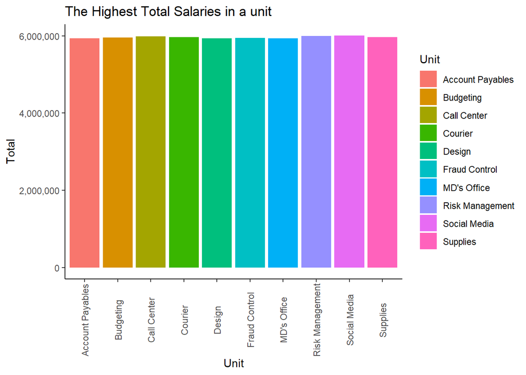

```r
unit_total_max_graph <- unit_total_max %>%
  ggplot(aes(Unit,Total,fill = Unit)) +
  geom_col() +
  scale_y_continuous(labels = scales::comma)+
  ggtitle("The Highest Total Salaries in a unit") +
  theme_classic() + theme(axis.text.x = element_text(angle = 90, vjust = 0.5))


unit_total_max_graph
```

```r
unit_total_min  <- salary %>%
  aggregate(Total~Unit,FUN = min) %>%
  arrange(Total) %>% head(10)

unit_total_min
```

```
##                      Unit    Total
## 1             Expenditure 260788.0
## 2                 Payroll 324092.5
## 3              Compliance 324432.9
## 4                  Design 325099.9
## 5  Training & Development 325234.0
## 6     Account Receivables 347672.5
## 7            Social Media 350660.9
## 8                Training 351044.5
## 9               Budgeting 352671.1
## 10        Desktop Support 357395.7
```

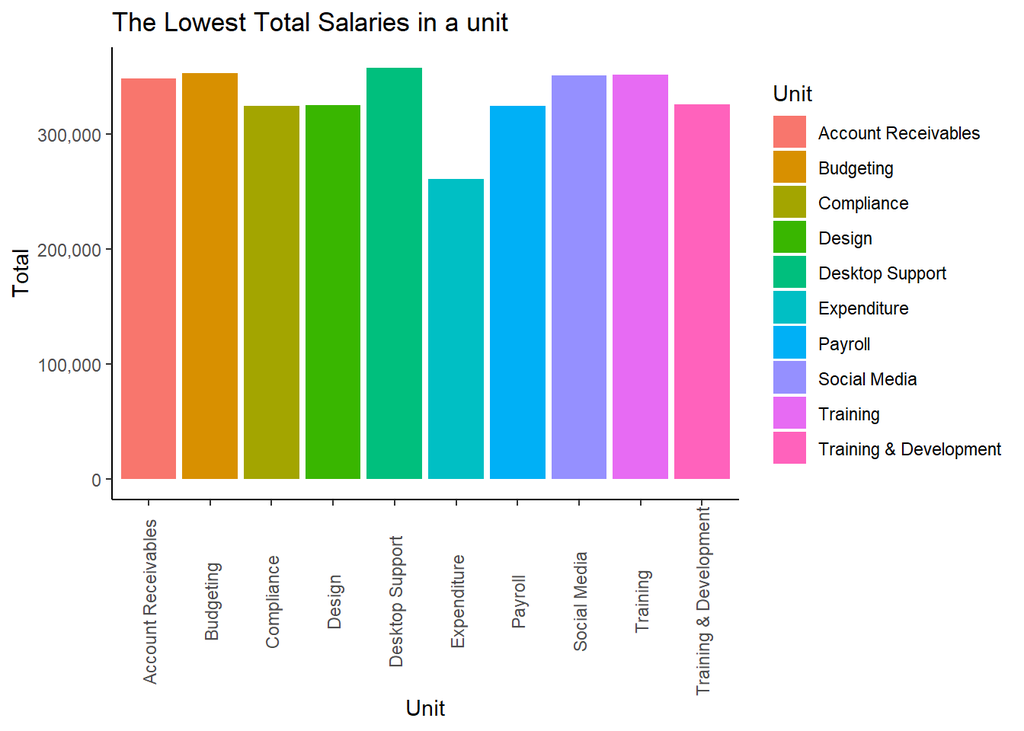

```r
unit_total_min_graph <- unit_total_min %>%
  ggplot(aes(Unit,Total,fill = Unit)) +
  geom_col() +
  scale_y_continuous(labels = scales::comma) +
  ggtitle("The Lowest Total Salaries in a unit") +  theme_classic() +
  theme(axis.text.x = element_text(angle = 90, vjust = 0.5))


unit_total_min_graph
```

***

### Top Earning Employees

```r
employee_pay_max <-  salary %>%
  select(`First Name`,
         Surname,
         Department,
         Unit,
         Basic,
         Total) %>%
  arrange(desc(Total)) %>%
  head(10)

employee_pay_max
```

```
## # A tibble: 10 × 6
##    `First Name`  Surname         Department       Unit              Basic  Total
##    <chr>         <chr>           <chr>            <chr>             <dbl>  <dbl>
##  1 Oluwafolakemi Ademola         Customer Service Social Media     4.97e6 6.00e6
##  2 Francis       Babalola        Internal Control Risk Management  4.97e6 6.00e6
##  3 Chidozie      Adeko           Customer Service Call Center      4.96e6 5.99e6
##  4 Umoh          Umoh            Admin.           Supplies         4.95e6 5.97e6
##  5 Ago           Ago             Dispatch         Courier          4.95e6 5.97e6
##  6 Ijisesan      Godwin          Customer Service Call Center      4.94e6 5.96e6
##  7 James         Ubong           Finance          Budgeting        4.94e6 5.96e6
##  8 Chiamaka      Okhiona         Internal Control Fraud Control    4.92e6 5.94e6
##  9 Chigozie      Lemmy-Johnson   Finance          Account Payables 4.92e6 5.94e6
## 10 Shahidul      Dibosa-Osadolor Admin.           MD's Office      4.92e6 5.93e6
```

### Low Earning Employees

```r
employee_pay_min <-  salary %>%
  select(`First Name`,
         Surname,
         Department,
         Unit,
         Basic,
         Total) %>%
  arrange(Total) %>%
  head(10)

employee_pay_min
```

```
## # A tibble: 10 × 6
##    `First Name` Surname   Department       Unit                     Basic  Total
##    <chr>        <chr>     <chr>            <chr>                    <dbl>  <dbl>
##  1 Nwelih       Thompson  Admin.           Expenditure             58976. 2.61e5
##  2 Omoyeni      Rosemary  Human Resources  Payroll                104316  3.24e5
##  3 Babatunde    Bisah     Internal Control Compliance             104608  3.24e5
##  4 Danjuma      Ogbuefi   R&D              Design                 105180  3.25e5
##  5 Chidi        Izevbigie Human Resources  Training & Development 105295  3.25e5
##  6 Busari       Ewuola    Finance          Account Receivables    124539  3.48e5
##  7 Mary         Ado       Customer Service Social Media           127102  3.51e5
##  8 Oluseun      Afolayan  Quality Control  Training               127431  3.51e5
##  9 Ernest       Usen      Finance          Budgeting              128826  3.53e5
## 10 Stanley      Coker     IT               Desktop Support        132878  3.57e5
```

# Data Analysis Report

## Analysis of Departmental Compensation

### Introduction

This report aims to analyze and derive insights from the compensation levels across various departments within the organization. The focus is on understanding the disparities in base salaries among departments and identifying patterns and trends in compensation distribution.

### Summary of Findings

Upon analyzing the base salary data, it is observed that most departments exhibit relatively high levels of compensation. The variations in base salaries across different departments are minimal, indicating a relatively equitable distribution of pay within the organization. However, there are some notable differences in the average base salaries among specific departments.

### Detailed Findings

1. *Average Base Salary Comparison*:
   - The average base salary across the departments shows little variation, suggesting that the organization maintains a consistent pay structure.
   - Departments such as *Internal Control* and *IT* have the lowest average base salaries. This finding highlights a potential area for review to ensure these departments are adequately compensated for their contributions.
2. *Highest Average Base Salaries*:
   - The *Dispatch* and *Quality Control* departments have the highest average base salaries. These departments may involve specialized skills or critical functions that justify higher compensation levels.
3. *Difference Between Highest and Lowest Base Salaries*:
   - The difference between the highest base salary and the average base salary is low but not as low as the lowest base salary. This indicates that while there is some variation, the overall spread of base salaries is kept within a reasonable range.
4. *Unit-Level Salary Discrepancies*:
   - Some units within their respective departments have very low salaries compared to the average salary in their units. This intra-departmental disparity suggests that certain roles or positions may not be compensated as competitively as others within the same department.

### Conclusion

In conclusion, the analysis indicates that there is a relatively equitable distribution of base compensation across the departments, with minor variations. The *Dispatch* and *Quality Control* departments lead with the highest average base salaries, while *Internal Control* and *IT* have the lowest. Additionally, it is noted that some units within departments experience significant salary discrepancies, which could affect employee satisfaction and retention.

### Recommendations

1. *Review Compensation for Lower Paid Departments and Units*:
   - Conduct a further review of the compensation structure for the *Internal Control* and *IT* departments, as well as for units with significantly lower salaries within their respective departments, to ensure pay aligns with industry standards and internal equity.
2. *Address Unit-Level Discrepancies*:
   - Implement targeted adjustments for units with notably low salaries within their departments to reduce intra-departmental disparities and promote fairness.
3. *Maintain Equity in Pay Structure*:
   - Continue monitoring and adjusting the compensation policies to maintain a fair and equitable pay structure across all departments and units, ensuring all employees feel valued and adequately compensated for their work.

This analysis serves as a foundational step in understanding and addressing compensation disparities within the organization, aiming to foster a fair and motivating work environment.